# Lab 3 Key

Prof. Amanda D. Perez, PhD

# Setting Up: Correlations

## Libraries

```r
library(tidyverse)
library(psych)
library(scales)
library(forcats)
library(viridis)
```

## Billboard Music Data

For this section you will be using Billboard music data from TidyTuesday. See https://github.com/rfordatascience/tidytuesday/tree/master/data/2021/2021-09-14 for more detailed information about the dataset.

```r
set.seed(8765)
billboard <- readr::read_csv('https://raw.githubusercontent.com/rfordatascience/tidytuesday/master/data/2021/2021-09-14/audio_features.csv') %>% sample_n(5000)
```

Let’s glimpse at the data.

```r
glimpse(billboard)
```

```
## Rows: 5,000
## Columns: 22
## $ song_id                   <chr> "Magic ManHeart", "Light Up The WorldGlee Ca…
## $ performer                 <chr> "Heart", "Glee Cast", "Phil Vassar", "Cathy …
## $ song                      <chr> "Magic Man", "Light Up The World", "Last Day…
## $ spotify_genre             <chr> "['folk-pop', 'indie folk', 'indie pop', 'ne…
## $ spotify_track_id          <chr> "4sUlsy0tPv9n5nqrqeA0lE", "1Et2wMhDPqbu5y4sG…
## $ spotify_track_preview_url <chr> NA, "https://p.scdn.co/mp3-preview/b009108a2…
## $ spotify_track_duration_ms <dbl> 328360, 223653, 234306, NA, 46253, NA, 16062…
## $ spotify_track_explicit    <lgl> FALSE, FALSE, FALSE, NA, FALSE, NA, FALSE, F…
## $ spotify_track_album       <chr> "Dreamboat Annie", "Glee: The Musi", "Totall…
## $ danceability              <dbl> 0.435, 0.689, 0.557, NA, 0.632, NA, 0.615, 0…
## $ energy                    <dbl> 0.444, 0.796, 0.549, NA, 0.323, NA, 0.479, 0…
## $ key                       <dbl> 7, 10, 0, NA, 10, NA, 7, 2, 8, 9, 5, 2, 5, 9…
## $ loudness                  <dbl> -12.816, -5.472, -6.674, NA, -14.042, NA, -8…
## $ mode                      <dbl> 0, 1, 1, NA, 0, NA, 1, 1, 0, 0, 1, 0, 1, 0, …
## $ speechiness               <dbl> 0.0336, 0.0406, 0.0246, NA, 0.9510, NA, 0.06…
## $ acousticness              <dbl> 0.159000, 0.000599, 0.272000, NA, 0.811000, …
## $ instrumentalness          <dbl> 7.05e-04, 0.00e+00, 0.00e+00, NA, 0.00e+00, …
## $ liveness                  <dbl> 0.4570, 0.1200, 0.1090, NA, 0.1020, NA, 0.27…
## $ valence                   <dbl> 0.734, 0.857, 0.268, NA, 0.769, NA, 0.788, 0…
## $ tempo                     <dbl> 103.818, 118.029, 139.945, NA, 171.053, NA, …
## $ time_signature            <dbl> 4, 4, 3, NA, 4, NA, 4, 3, 4, 4, 4, 4, 4, 4, …
## $ spotify_track_popularity  <dbl> 59, 48, 30, NA, 18, NA, 45, 14, 63, 63, 51, …
```

## Correlation 1

### Exercise 1 -

Use the `cor.test()` function to run a correlation. Select any two numeric variables of interest for your correlation. Interpret the output in terms of significance and direction.

```r
cor.test(billboard$spotify_track_duration_ms,
         billboard$spotify_track_popularity)
```

```
##
##  Pearson's product-moment correlation
##
## data:  billboard$spotify_track_duration_ms and billboard$spotify_track_popularity
## t = 10.871, df = 4147, p-value < 2.2e-16
## alternative hypothesis: true correlation is not equal to 0
## 95 percent confidence interval:
##  0.1367243 0.1958990
## sample estimates:
##       cor
## 0.1664615
```

**INTERPRETATION:** There is a small, significant (p < 0.05) positive correlation between track popularity and track duration. (ANSWER WILL DEPEND ON VARIABLES CHOSEN).

### Exercise 2 -

Create a ggplot scatterplot visualization of the two variables you selected for the correlation. Add a geom_smooth regression “lm” line to the plot. Interpret what you see. Make sure you clean up the labels and add a theme.

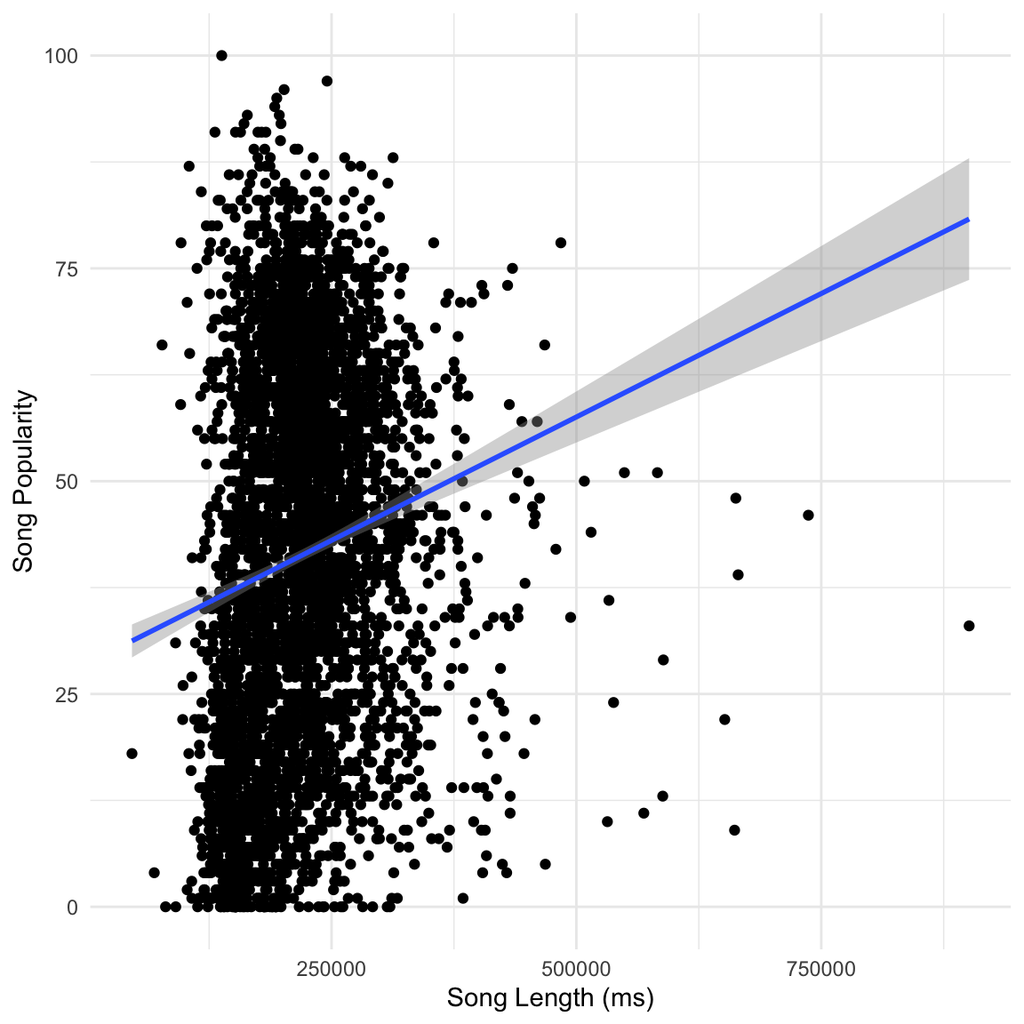

```r
ggplot(billboard, aes(spotify_track_duration_ms,
                  spotify_track_popularity)) +
  geom_point() +
  theme_minimal() +
  geom_smooth(method = "lm") +
  labs(x = "Song Length (ms)", y = "Song Popularity")
```

**INTERPRETAION:** While it is positive, we see most of the song length clustering is around 250000 ms. (ANSWER WILL DEPEND ON VARIABLES CHOSEN).

## Correlation 2

### Exercise 3 -

Use the `cor.test()` function to run a different correlation. Select any two numeric variables of interest (different from exercise 1) for your correlation. Interpret the output in terms of significance and direction.

```r
cor.test(billboard$energy, billboard$loudness)
```

```
##
##  Pearson's product-moment correlation
##
## data:  billboard$energy and billboard$loudness
## t = 61.435, df = 4133, p-value < 2.2e-16
## alternative hypothesis: true correlation is not equal to 0
## 95 percent confidence interval:
##  0.6746030 0.7064815
## sample estimates:
##       cor
## 0.6908779
```

**INTERPRETATION:** There is a strong positive and significant (p < 0.05) correlation between the energy and loudness of a song. (ANSWER WILL DEPEND ON VARIABLES CHOSEN).

### Exercise 4 -

Create a ggplot scatterplot visualization of the two variables you selected for the previous correlation. Add a geom_smooth regression “lm” line to the plot. Interpret what you see. Make sure you clean up the labels and add a theme.

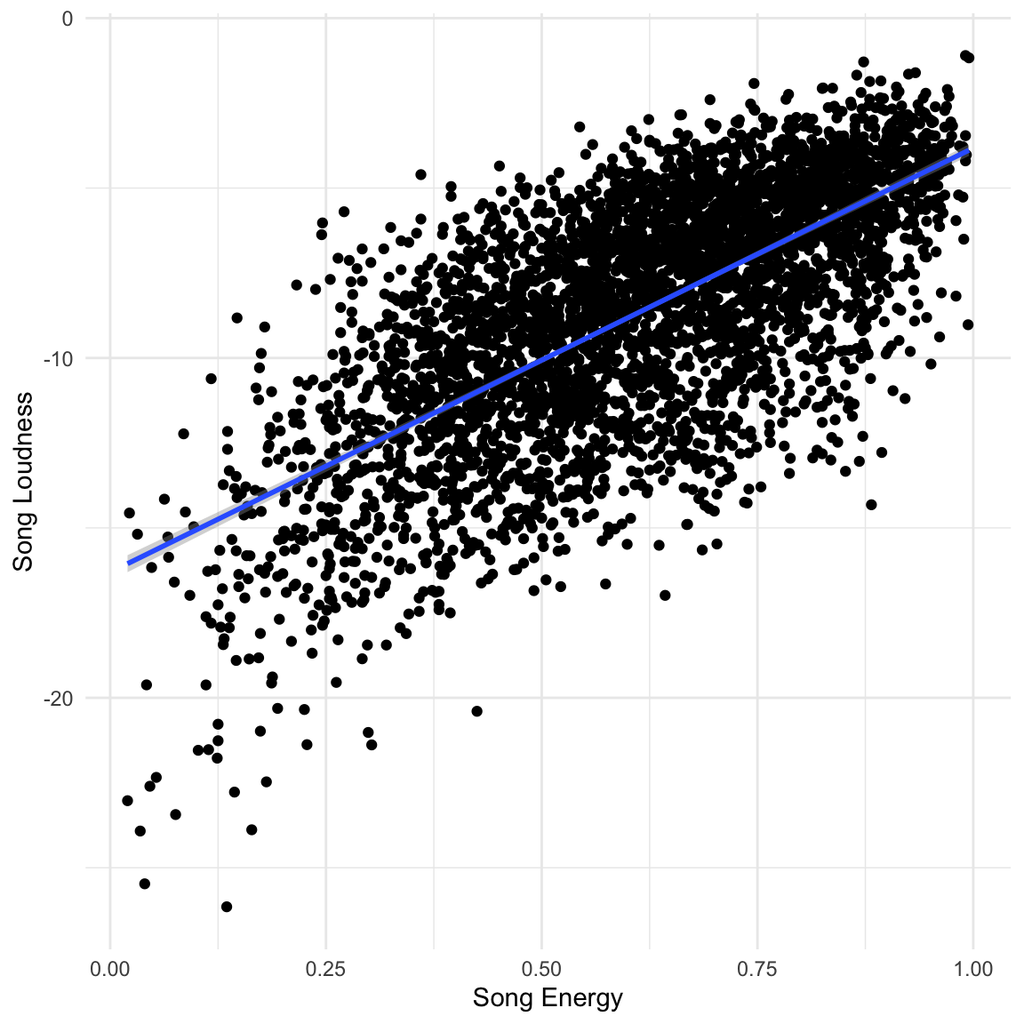

```r
ggplot(billboard, aes(energy, loudness)) +
  geom_point() +
  theme_minimal() +
  geom_smooth(method = "lm") +
  labs(x = "Song Energy", y = "Song Loudness")
```

**INTERPRETATION:** Similar to the correlation output, we see a strong positive linear relationship between the two variables. (ANSWER WILL DEPEND ON VARIABLES CHOSEN).

## Correlation 3

### Exercise 5 -

Use the `cor.test()` function to run a different correlation. Select any two numeric variables of interest (different from exercise 1 & 3) for your correlation. Interpret the output in terms of significance and direction.

```r
cor.test(billboard$instrumentalness, billboard$valence)
```

```
##
##  Pearson's product-moment correlation
##
## data:  billboard$instrumentalness and billboard$valence
## t = 3.3479, df = 4133, p-value = 0.0008215
## alternative hypothesis: true correlation is not equal to 0
## 95 percent confidence interval:
##  0.02155890 0.08235676
## sample estimates:
##        cor
## 0.05200602
```

**INTERPRETATION:** There is a weak positive significant correlation between the valence and intrumentalness of a song. (ANSWER WILL DEPEND ON VARIABLES CHOSEN).

### Exercise 6 -

Create a ggplot scatterplot visualization of the two variables you selected for the previous correlation. Add a geom_smooth regression “lm” line to the plot. Interpret what you see. Make sure you clean up the labels and add a theme.

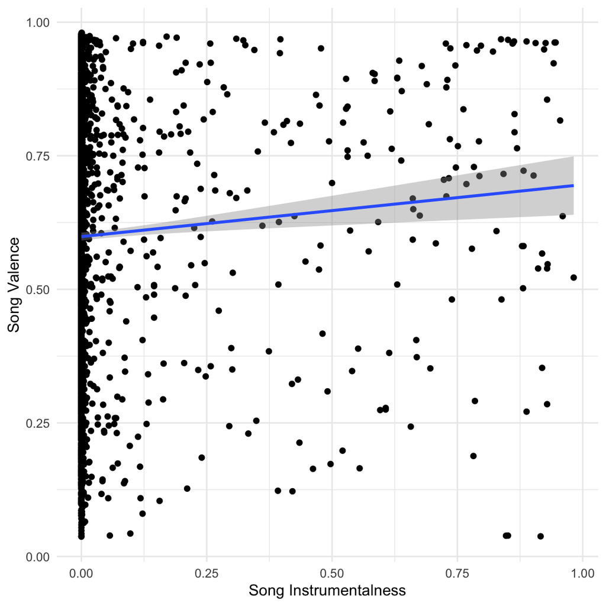

```r
ggplot(billboard, aes(instrumentalness, valence)) +
  geom_point() +
  theme_minimal() +
  geom_smooth(method = "lm") +
  labs(x = "Song Instrumentalness", y = "Song Valence")
```

**INTERPRETATION:** The intrumentalness score have a strong cluster around 0. (ANSWER WILL DEPEND ON VARIABLES CHOSEN).

## Correlation 4

### Exercise 7 -

Use the `cor.test()` function to run a different correlation. Select any two numeric variables of interest (different from exercise 1 & 3 & 5) for your correlation. Interpret the output in terms of significance and direction.

```r
cor.test(billboard$tempo, billboard$energy)
```

```
##
##  Pearson's product-moment correlation
##
## data:  billboard$tempo and billboard$energy
## t = 10.532, df = 4133, p-value < 2.2e-16
## alternative hypothesis: true correlation is not equal to 0
## 95 percent confidence interval:
##  0.1318425 0.1912131
## sample estimates:
##       cor
## 0.1616741
```

**INTERPRETATION:** There is a small positive significant relationship between the tempo and energy of a song. (ANSWER WILL DEPEND ON VARIABLES CHOSEN).

### Exercise 8 -

Create a ggplot scatterplot visualization of the two variables you selected for the previous correlation. Add a geom_smooth regression “lm” line to the plot. Interpret what you see. Make sure you clean up the labels and add a theme.

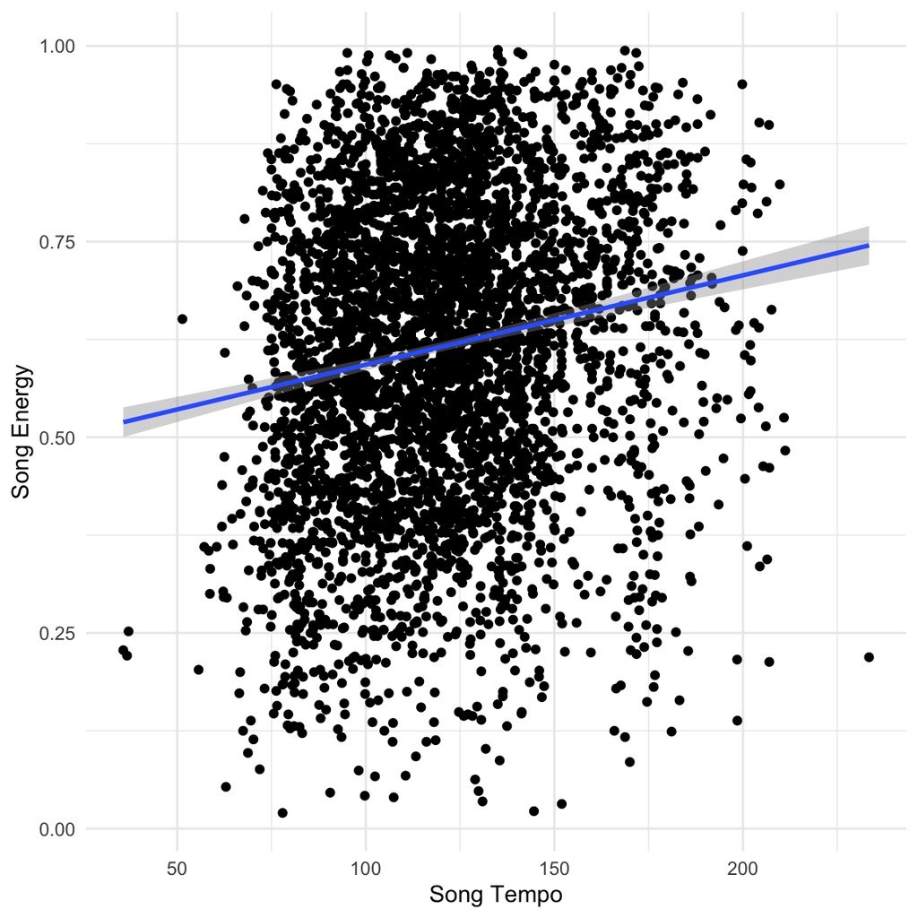

```r
ggplot(billboard, aes(tempo, energy)) +
  geom_point() +
  theme_minimal() +
  geom_smooth(method = "lm") +
  labs(x = "Song Tempo", y = "Song Energy")
```

**INTERPRETATION:** While there is a big circular cluster in the middle, we do still see a slight positive trend happening between the two variables. (ANSWER WILL DEPEND ON VARIABLES CHOSEN).

# Setting Up: T-Tests

```r
library(tidyverse)
library(ggplot2)
library(scales)
library(lsr)
set.seed(8765)
nurses <- readr::read_csv('https://raw.githubusercontent.com/rfordatascience/tidytuesday/master/data/2021/2021-10-05/nurses.csv')
nurses$Year <- as.factor(nurses$Year)
nurses$State <- as.factor(nurses$State)

glimpse(nurses)
```

```
## Rows: 1,242
## Columns: 22
## $ State                                             <fct> Alabama, Alaska, Ari…
## $ Year                                              <fct> 2020, 2020, 2020, 20…
## $ `Total Employed RN`                               <dbl> 48850, 6240, 55520, …
## $ `Employed Standard Error (%)`                     <dbl> 2.9, 13.0, 3.7, 4.2,…
## $ `Hourly Wage Avg`                                 <dbl> 28.96, 45.81, 38.64,…
## $ `Hourly Wage Median`                              <dbl> 28.19, 45.23, 37.98,…
## $ `Annual Salary Avg`                               <dbl> 60230, 95270, 80380,…
## $ `Annual Salary Median`                            <dbl> 58630, 94070, 79010,…
## $ `Wage/Salary standard error (%)`                  <dbl> 0.8, 1.4, 0.9, 1.4, …
## $ `Hourly 10th Percentile`                          <dbl> 20.75, 31.50, 27.66,…
## $ `Hourly 25th Percentile`                          <dbl> 23.73, 36.94, 32.58,…
## $ `Hourly 75th Percentile`                          <dbl> 33.15, 53.31, 44.67,…
## $ `Hourly 90th Percentile`                          <dbl> 38.67, 60.70, 50.14,…
## $ `Annual 10th Percentile`                          <dbl> 43150, 65530, 57530,…
## $ `Annual 25th Percentile`                          <dbl> 49360, 76830, 67760,…
## $ `Annual 75th Percentile`                          <dbl> 68960, 110890, 92920…
## $ `Annual 90th Percentile`                          <dbl> 80420, 126260, 10429…
## $ `Location Quotient`                               <dbl> 1.20, 0.98, 0.91, 1.…
## $ `Total Employed (National)_Aggregate`             <dbl> 140019790, 140019790…
## $ `Total Employed (Healthcare, National)_Aggregate` <dbl> 8632190, 8632190, 86…
## $ `Total Employed (Healthcare, State)_Aggregate`    <dbl> 128600, 17730, 17101…
## $ `Yearly Total Employed (State)_Aggregate`         <dbl> 1903210, 296300, 283…
```

## Exercise 9 - Select States

First we will run a t-test comparing two means of `Hourly Wage Avg`. Your first task is to pick two U.S. states that you want to compare. Look at the output of the levels command below and select two states that are of interest to you.

```r
levels(nurses$State)
```

```
##  [1] "Alabama"              "Alaska"               "Arizona"
##  [4] "Arkansas"             "California"           "Colorado"
##  [7] "Connecticut"          "Delaware"             "District of Columbia"
## [10] "Florida"              "Georgia"              "Guam"
## [13] "Hawaii"               "Idaho"                "Illinois"
## [16] "Indiana"              "Iowa"                 "Kansas"
## [19] "Kentucky"             "Louisiana"            "Maine"
## [22] "Maryland"             "Massachusetts"        "Michigan"
## [25] "Minnesota"            "Mississippi"          "Missouri"
## [28] "Montana"              "Nebraska"             "Nevada"
## [31] "New Hampshire"        "New Jersey"           "New Mexico"
## [34] "New York"             "North Carolina"       "North Dakota"
## [37] "Ohio"                 "Oklahoma"             "Oregon"
## [40] "Pennsylvania"         "Puerto Rico"          "Rhode Island"
## [43] "South Carolina"       "South Dakota"         "Tennessee"
## [46] "Texas"                "Utah"                 "Vermont"
## [49] "Virgin Islands"       "Virginia"             "Washington"
## [52] "West Virginia"        "Wisconsin"            "Wyoming"
```

```r
state_nurses <- nurses %>%
  filter(State == "California" |
           State == "Arizona")

state_nurses$State <- droplevels(state_nurses$State)
```

## Exercise 10 - Nurse Hourly Wage t-test

Now you run your t-test. Your goal is to test if there is a significant difference in `Hourly Wage Avg` based on the states (`State`) you selected. *Note:* You will have to write the variable name `Hourly Wage Avg` in the code below within back-ticks “`” because the variable name contains spaces.

```r
t.test(`Hourly Wage Avg` ~ State, data = state_nurses)
```

```
##
##  Welch Two Sample t-test
##
## data:  Hourly Wage Avg by State
## t = -4.0538, df = 35.925, p-value = 0.0002583
## alternative hypothesis: true difference in means between group Arizona and group California is not equal to 0
## 95 percent confidence interval:
##  -14.532362  -4.839811
## sample estimates:
##    mean in group Arizona mean in group California
##                 30.36348                 40.04957
```

## Exercise 11 - Interpret Nurse Hourly Wage t-test

**INTERPRETATION:** Interpret the above t-test results. (ANSWER WILL DEPEND ON STATES CHOSEN)

## Exercise 12 - Graphing Nurse Hourly Wage

Below I have created a basic ggplot code chunk to observe the differences. Your task is to improve the graph by: Cleaning up all of the labels, adding a title, make each bar a different color, and add a theme. See https://ggplot2-book.org/polishing.html for a list of included themes. Finally, interpret what you see.

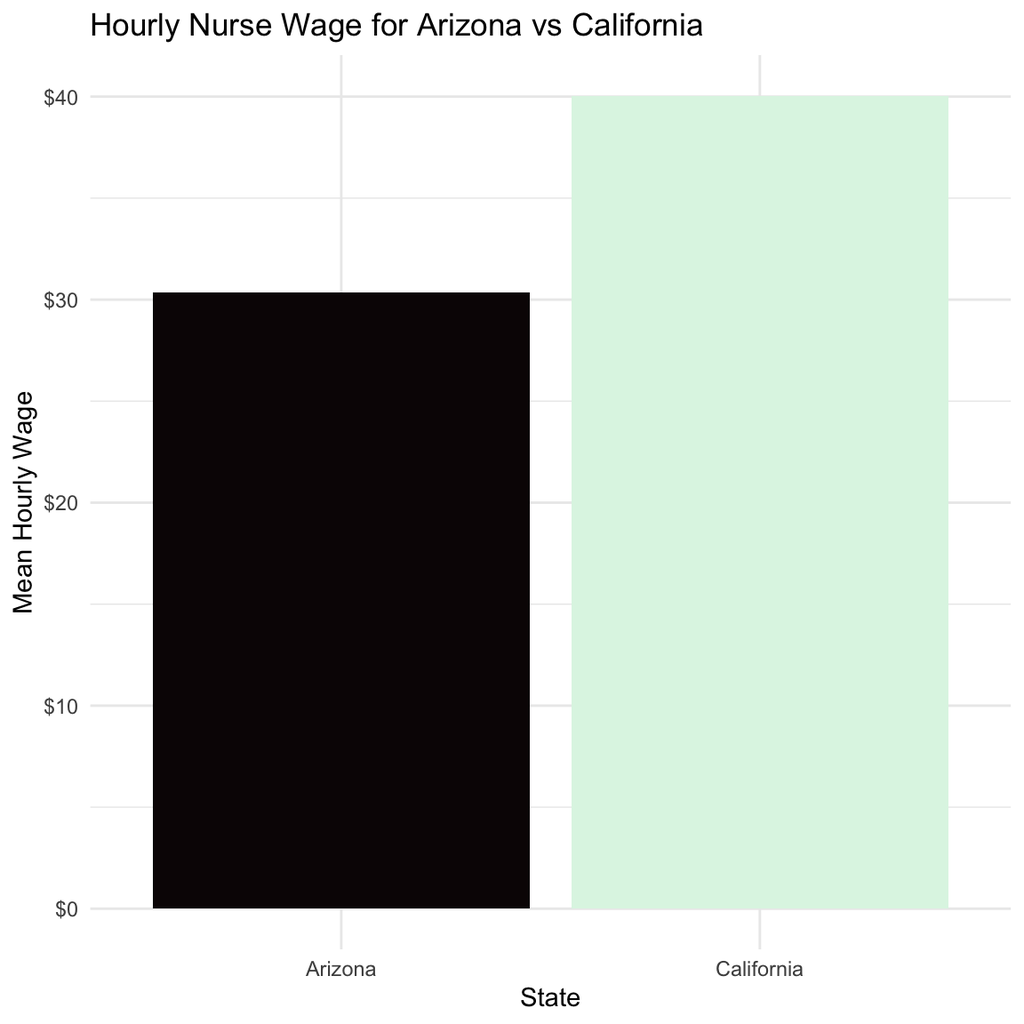

```r
ggplot(state_nurses, aes(State, `Hourly Wage Avg`, fill = State)) +
  stat_summary(fun = mean, geom = "bar") +
  guides(fill = "none") +
  theme_minimal() +
  scale_fill_viridis_d(option = "mako") +
  labs(x = "State", y = "Mean Hourly Wage", title = "Hourly Nurse Wage for Arizona vs California ") +
  scale_y_continuous(labels = dollar_format())
```

**INTERPRETATION:** (ANSWER WILL DEPEND ON STATES CHOSEN)

## Exercise 13 - Select Years

Next we will run a t-test comparing two means of `Annual Salary Avg`. Your first task is to pick two years that you want to compare. Look at the output of the levels command below and select two years that are of interest to you.

```r
levels(nurses$Year)
```

```
##  [1] "1998" "1999" "2000" "2001" "2002" "2003" "2004" "2005" "2006" "2007"
## [11] "2008" "2009" "2010" "2011" "2012" "2013" "2014" "2015" "2016" "2017"
## [21] "2018" "2019" "2020"
```

In order to run a t-test, our grouping variable (`Year`) can only have two levels. We currently have 23. Below I am creating a new dataset called `year_nurses` that we will use only in this exercise and exercise 10. Fill in and replace “YEAR ONE” and “YEAR TWO” with the two years you selected.

```r
year_nurses <- nurses %>%
  filter(Year == "2011" |
           Year == "2015")

year_nurses$Year <- droplevels(year_nurses$Year)
```

## Exercise 14 - Nurse Annual Salary t-test

Now you run your t-test. This time I am not providing you any starting code. Your goal is to test if there is a significant difference in `Annual Salary Avg` based on the two years you selected. Interpret the t-test results. *Note:* You will have to write the variable name `Annual Salary Avg` in the code below within back-ticks “`” because the variable name contains spaces.

```r
t.test(`Annual Salary Avg` ~ Year, data = year_nurses)
```

```
##
##  Welch Two Sample t-test
##
## data:  Annual Salary Avg by Year
## t = -0.48043, df = 103.45, p-value = 0.6319
## alternative hypothesis: true difference in means between group 2011 and group 2015 is not equal to 0
## 95 percent confidence interval:
##  -5126.916  3127.287
## sample estimates:
## mean in group 2011 mean in group 2015
##           65607.41           66607.22
```

## Exercise 15 - Interpret Nurse Annual Salary t-test

**INTERPRETATION:** Interpret the above t-test results. (ANSWER WILL DEPEND ON YEARS CHOSEN)

## Exercise 16 - Graphing Nurse Annual Salary

Next, create a ggplot visualization showing the difference in the two means from exercise 14/15. This time I am not providing any starting code. *Hint: You can copy and paste the code from the previous t-test graph and swap out the variable names.*

Make sure you: Cleaning up all of the labels, adding a title, make each bar a different color, and add a theme. See https://ggplot2-book.org/polishing.html for a list of included themes.

Finally, interpret what you see.

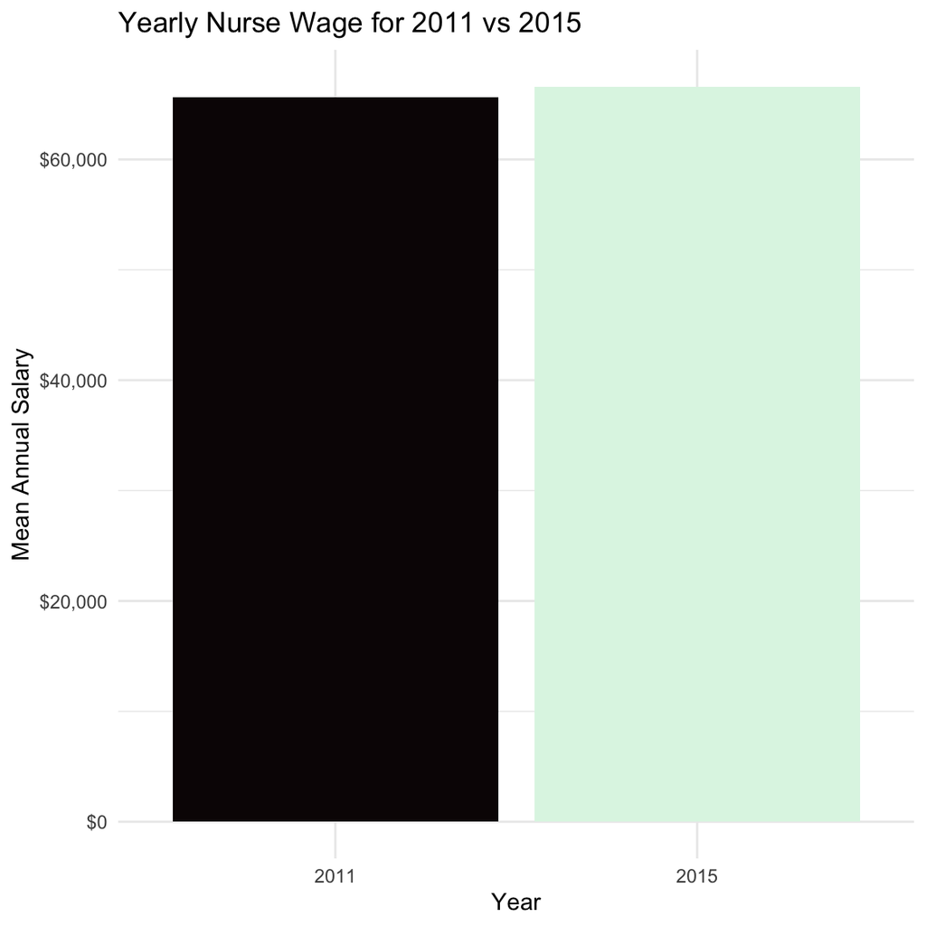

```r
ggplot(year_nurses, aes(Year, `Annual Salary Avg`, fill = Year)) +
  stat_summary(fun = mean, geom = "bar") +
  guides(fill = "none") +
  theme_minimal() +
  scale_fill_viridis_d(option = "mako") +
  labs(x = "Year", y = "Mean Annual Salary", title = "Yearly Nurse Wage for 2011 vs 2015 ") +
  scale_y_continuous(labels = dollar_format())
```

**INTERPRETATION:** Interpret the above t-test results. (ANSWER WILL DEPEND ON YEARS CHOSEN)

## Exercise 17 - Cohens D Nurse Hourly Wage

Use the `cohensD` function from the `lsr` library to get the effect size. Make sure you set `method = "unequal"`. Interpret the size of the effect.

```r
cohensD(`Hourly Wage Avg` ~ State, data = state_nurses, method = "unequal")
```

```
## [1] 1.195393
```

**INTERPRETATION:** Interpret the above results. (ANSWER WILL DEPEND ON STATES CHOSEN).

## Exercise 18 - Cohens D Nurse Annual Salary

Use the `cohensD` function from the `lsr` library to get the effect size. Make sure you set `method = "unequal"`. Interpret the size of the effect.

```r
cohensD(`Annual Salary Avg` ~ Year, data = year_nurses, method = "unequal")
```

```
## [1] 0.09245932
```

**INTERPRETATION:** Interpret the above results. (ANSWER WILL DEPEND ON YEARS CHOSEN)

# Setting Up: Recoding Data

For this section we will be working with a dataset about penguins.Run the below code chunk to `glimpse()` the data.

```r
library(palmerpenguins)
glimpse(penguins)
```

```
## Rows: 344
## Columns: 8
## $ species           <fct> Adelie, Adelie, Adelie, Adelie, Adelie, Adelie, Adel…
## $ island            <fct> Torgersen, Torgersen, Torgersen, Torgersen, Torgerse…
## $ bill_length_mm    <dbl> 39.1, 39.5, 40.3, NA, 36.7, 39.3, 38.9, 39.2, 34.1, …
## $ bill_depth_mm     <dbl> 18.7, 17.4, 18.0, NA, 19.3, 20.6, 17.8, 19.6, 18.1, …
## $ flipper_length_mm <int> 181, 186, 195, NA, 193, 190, 181, 195, 193, 190, 186…
## $ body_mass_g       <int> 3750, 3800, 3250, NA, 3450, 3650, 3625, 4675, 3475, …
## $ sex               <fct> male, female, female, NA, female, male, female, male…
## $ year              <int> 2007, 2007, 2007, 2007, 2007, 2007, 2007, 2007, 2007…
```

### Exercise 19: Renaming Columns

We want to rename **all** of the columns! Change `species` to `Species`, `island` to `Island`, `bill_length_mm` to `Bill Length (mm)`, `bill_depth_mm` to `Bill Depth (mm)`, `flipper_length_mm` to `Flipper Length (mm)`, `body_mass_g` to `Body Mass (g)`, `sex` to `Sex`, `year` to `Year`. You must start your code with: `penguins_renamed <- penguins %>%` in order to save these changes to a new dataset called `penguins_renamed`. You will use the `rename()` function to accomplish this.

```r
penguins_renamed <- penguins %>%
  rename(
    Species = `species`,
    Island = `island`,
    `Bill Length (mm)` = `bill_length_mm`,
    `Bill Depth (mm)` = `bill_depth_mm`,
    `Flipper Length (mm)` = `flipper_length_mm`,
    `Body Mass (g)` = `body_mass_g`,
    `Sex` = `sex`,
    `Year` = `year`
  )

head(penguins_renamed)
```

```
## # A tibble: 6 × 8
##   Species Island    `Bill Length (mm)` `Bill Depth (mm)` `Flipper Length (mm)`
##   <fct>   <fct>                  <dbl>             <dbl>                 <int>
## 1 Adelie  Torgersen               39.1              18.7                   181
## 2 Adelie  Torgersen               39.5              17.4                   186
## 3 Adelie  Torgersen               40.3              18                     195
## 4 Adelie  Torgersen               NA                NA                      NA
## 5 Adelie  Torgersen               36.7              19.3                   193
## 6 Adelie  Torgersen               39.3              20.6                   190
## # … with 3 more variables: Body Mass (g) <int>, Sex <fct>, Year <int>
```

### Exercise 20: Calculating Frequenies

Now, using the new `penguins_renamed` dataset do the following:

- `group_by` Sex, and then
- `filter` with the argument `!is.na(Sex)` inside of the `filter` parentheses. This will remove penguins with no recorded sex from showing up.
- Use `summarize` to calculate the percentage of penguins. `group_by` will do this separately for male versus female penguins automatically. Inside of the parentheses, first add a label for the name of this new column. For example, you could name it Percent. Then, add an `=` and fill in an equation that will calculate the percentage. You will use this format: `n()/nrow(CODEHERE)*100`. Where it says `CODEHERE` put in the name of the dataset we are working with. This formula will take the `n()` of each group (how many males versus females in the dataset), divide it by the total sample size with `nrow()`, and multiply it by 100 to get the percentage with `*100`.

```r
penguins_renamed %>%
  group_by(Sex) %>%
  filter(!is.na(Sex)) %>%
  summarize(Percent = n()/nrow(penguins_renamed)*100)
```

```
## # A tibble: 2 × 2
##   Sex    Percent
##   <fct>    <dbl>
## 1 female    48.0
## 2 male      48.8
```

### Exercise 21: Recoding Levels

For this exercise we want to recode the levels of the `Sex` variable. Run the levels command below.

```r
levels(as.factor(penguins_renamed$Sex))
```

```
## [1] "female" "male"
```

As you can see, the levels start with a lowercase letter. In the code chunk below, use `mutate` and `case_when` to change male to Male and female to Female. *Hint: there is an example of* `case_when()` in the lecture video on recoding data. Start your code with `penguins_renamed <- penguins_renamed %>%` to update these changes to the `penguins_renamed` dataset.

```r
penguins_renamed <- penguins_renamed %>%
  mutate(Sex = case_when(
    Sex == "male" ~ "Male",
    Sex == "female" ~ "Female",
  ))
```

### Exercise 22: Graphing

Finally, we want to customize a graph. Below I have created an initial template for you. Running this code will return a blank canvas of a graph. In order to complete the graph, add the following to the graph:

- inside of the first `aes()`, add on a `fill = Sex` argument inside of the parenthesis. Make sure to use a `,` after `Species` when adding this code.
- add on `+ geom_col()` to create a graph with columns. Inside of the parentheses, add `position = "fill"`.
- add on `+ scale_fill_viridis_d(option = "BLANK")` to change the colors of the graph. I have put a placeholder of `"BLANK"` for now. Replace this with one of the following: `"mako"`, `"magma"`, `"plasma"`, `"inferno"`, `"cividis"`, `"rocket"`, or `"turbo"`. These all represent different color options. Play around and pick the one you like best.
- and on a theme with `theme_BLANK()`. Replace the blank with one of the following: `minimal`, `bw`, `classic`, `dark`, `get`, `grey`, `gray`, `light`, `linedraw`, `replace`, `test`, or `update`.
- finally, add on `+ theme()` with `legend.position = "bottom"` set as the option inside of the parentheses.

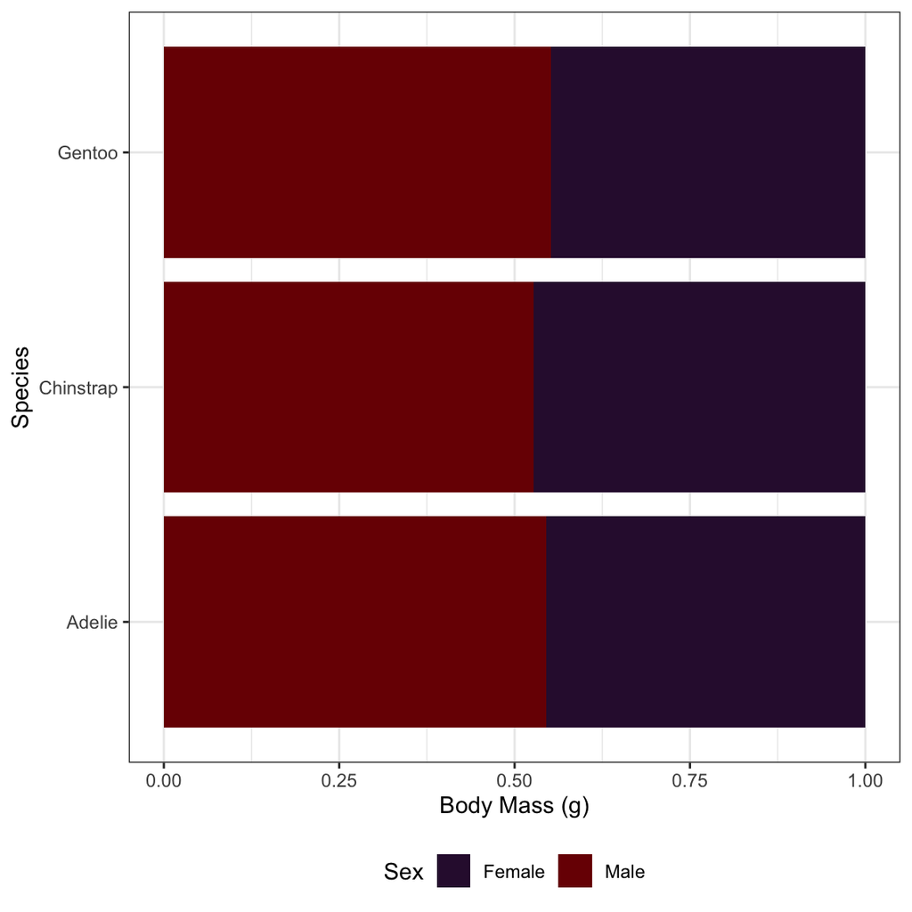

```r
ggplot(penguins_renamed %>% filter(!is.na(Sex)), aes(x = `Body Mass (g)`, y = Species, fill = Sex)) +
  geom_col(position = "fill") +
  scale_fill_viridis_d(option = "turbo") +
  theme_bw() +
  theme(legend.position =  "bottom")
```